# A8_Duong_Tram

TramooD17

15/03/2022

Assignment 8 - Metabarcoding

The Effects of Garlic Mustard on the Plant Community

Recently, the invasive plant species Alliaria petiolata, or garlic mustard, has been found in the Queen’s University Biological Station (QUBS) plant community.  
This report discusses the effects of garlic mustard on the QUBS plant community, if any, and - if there are any effects - whether it is the presence garlic mustard or the sampling population that has a stronger effect on plant communities.

The data set below contains the results of the conducted floristic survey:

```r
survey <- read.csv("./FloristicSurvey.csv")
```

The data contains the following parameters:  
Quadrate – code for the 1m x 1m square in which samples were measured  
Population – code for a specific sampling location at QUBS, determined by presence of garlic mustard nearby  
Location – whether quadrates were ‘i’ (‘inside’) or ‘o’ (‘outside’) of garlic mustard patches  
Rosettes – the number of garlic mustard rosettes  
Bolting – the number of garlic mustard plants getting ready to flower  
Budding – number of garlic mustard plants with buds  
Bud_Flw, Flower, Flw_Sil, Silique – different stages of flowering  
Claytonia, Anemone, … Unknown_9, mianthenum_racemosum – the 34 different species at all sites, where ‘Unknown’ is an unidentified species. All the sites with the same Unknown number have the respective species.

Question 1: What effect (if any) does garlic mustard have on the plant community?

Setup:

```r
library(ggplot2)
library(ape)
library(ggtree)
library(vegan)
```

A numeric- and species-only data frame and distance matrix are made:

```r
fsurvey <- subset(survey,select=-c(Quadrate,Location,Bud_Flw,Flower,Flw_Sil,Sillique))
sur_dist<- vegdist(fsurvey,method="bray",binary=F)
```

Non-metric multidimensional scaling is used to compare the composition of species per quadrate. The NMDS is generated:

```r
set.seed(13)
NMDSsurv <- metaMDS(sur_dist, k=2)
```

```
## *** Solution reached
```

```r
PDat <- data.frame(NMDS1=NMDSsurv$points[,1], NMDS2=NMDSsurv$points[,2], Population=row.names(fsurvey))
PDat<-merge(PDat,fsurvey,by="Population",all.x=T,all.y=F)
```

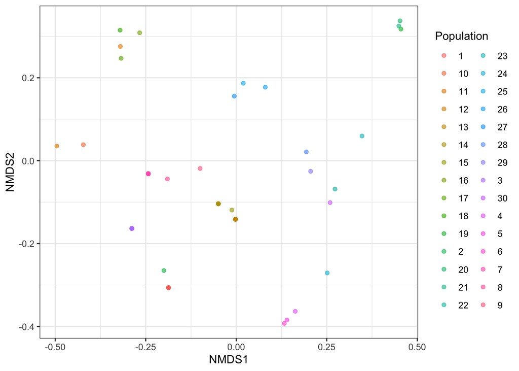

```r
qplot(x=NMDS1,y=NMDS2,colour=Population,alpha=I(0.6),data=PDat)+theme_bw()
```

Figure 1. NMDS1 plot which shows the similarity between specific locations at QUBS by plant species composition.

Question 2: What has a stronger effect on plant communities: the presence/absence of garlic mustard (in/out) or sampling population?

A neighbour-joining tree is generated to look at the relationship between garlic mustard presence and species composition.

```r
isurvey <- subset(survey,select=-c(Quadrate,Population,Bud_Flw,Flower,Flw_Sil,Sillique))
```

```r
survey_bin<-survey
for (i in 1:nrow(survey_bin)){
  for (j in 1:ncol(survey_bin)){
    if(survey_bin[i,j]>0){
      survey_bin[i,j]<-1
    }
  }
}
```

```r
sur_bin_dist<- dist(survey_bin,method="binary")
```

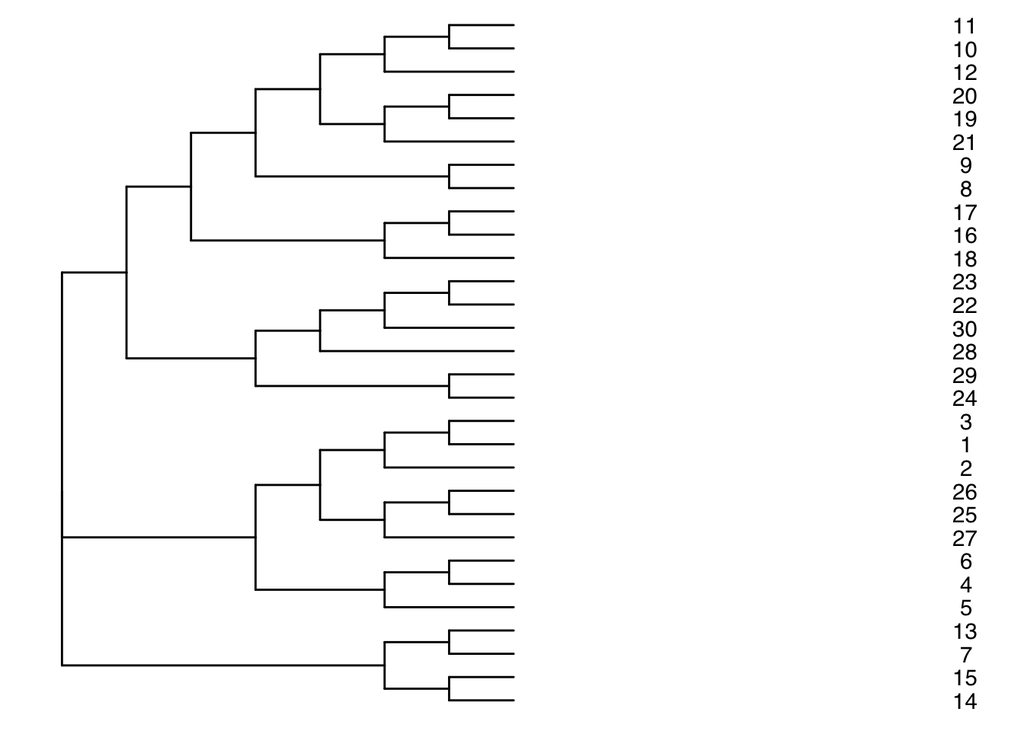

```r
sur_tree <- nj(sur_bin_dist)

dat <- data.frame(
  SPECIES = sur_tree$tip.label,
  PATTERN = sample(survey$Location, size = length(sur_tree$tip.label), replace = TRUE))

ggtree(sur_tree, layout="rectangular", branch.length = "none") %<+% survey + geom_tiplab(offset = 7, hjust = .6) + theme(legend.position = "right")
```